# CASE STUDY: How does a bike-share company navigate speedy success?

Author: Jai Mirchandani  
Date: 15th June, 2025

## Summary

*This case study explores Cyclistic bike-sharing data over a 12-month period to uncover trends in rider behavior. The objective is to compare casual vs member riders and provide actionable marketing recommendations to convert casual riders into annual members*.

## Company

In 2016, Cyclistic (fictional company) launched a successful bike-share offering. Since then, the program has grown to a fleet of 5,824 bicycles that are geotracked and locked into a network of 692 stations across Chicago. The bikes can be unlocked from one station and returned to any other station in the system anytime. Until now, Cyclistic’s marketing strategy relied on building general awareness and appealing to broad consumer segments. One approach that helped make these things possible was the exibility of its pricing plans: single-ride passes, full-day passes, and annual memberships. Customers who purchase single-ride or full-day passes are referred to as casual riders. Customers who purchase annual memberships are Cyclistic members.

## SCENARIO

Marketing director of cyclist believes the company’s future success depends on maximizing the number of annual memberships. Hence, a new data-driven marketing strategy is required to focus on increasing annual memberships. The marketing director further believes there is a solid opportunity to convert casual riders into members. Any marketing action must be approved by the executives and primary stakeholder and hence, a data-driven proof of marketing director's hypothesis is essential.

## Business Task

As a data analyst at this company my tasks are as follows:

- To compare the usage pattern of annual subscribers vs casual riders
- Prove the success rate of annual membership to the stakeholders of the company
- To reccomend the target audience within the casual riders for conversion into annual membership

## Datasets

1. Divy bike-sharing company trip data: https://divvy-tripdata.s3.amazonaws.com/index.html
- Data is stored in monthly tables From 06-2024 to 05-2025
- The data source is the official divvy database making it reliable and credible
2. New York Citibike public dataset: https://console.cloud.google.com/bigquery(cameo:product/city-of-new-york/nyc-citi-bike)
- Data is sourced, cleaned and analysed through big-query and later on imported here to visualize and interpret the insights

## DIVY Data Analysis

The data is stored in seperate tables for each month in the directory "divy_cycle_data"

```python
#IMPORTING LIBRARIES
%matplotlib inline
import numpy as np
import pandas as pd
import matplotlib.pyplot as plt
import os
from collections import Counter
```

```python
#Reading the data
Directory= 'divy_cycle_data/'
data_list=os.listdir(Directory)
for g in range(len(data_list)):
   globals()["divvy_"+str(g)] =pd.read_csv(Directory+data_list[g])
```

```python
#Merging the data into 1 single table
merged_divvy_data=pd.concat(globals()["divvy_"+str(g)] for g in range(len(data_list)))
#changing the data types
merged_divvy_data.dtypes
merged_divvy_data.started_at=pd.to_datetime(merged_divvy_data.started_at,format="%Y%m%d %H:%M:%S.%f")
merged_divvy_data.ended_at=pd.to_datetime(merged_divvy_data.ended_at,format="%Y%m%d %H:%M:%S.%f")
#Calculating the trip duration
merged_divvy_data['tripduration'] = (merged_divvy_data.ended_at-merged_divvy_data.started_at).dt.total_seconds() / 60
```

```python
#CHECK FOR ERRORS
print('Before removing duplicates=',len(merged_divvy_data))
merged_divvy_data.drop_duplicates
print('After removing duplicates=',len(merged_divvy_data))

print('tripduration_null=',merged_divvy_data.tripduration.isnull().sum())
print('date_null=',merged_divvy_data.started_at.isnull().sum())
print('membership_null=',merged_divvy_data.member_casual.isnull().sum())
```

```
Before removing duplicates= 5628847
After removing duplicates= 5628847
tripduration_null= 0
date_null= 0
membership_null= 0
```

```
Counter({'member': 3564561, 'casual': 2064286})
  member_casual  average_trip_duration
0        casual              24.105187
1        member              12.297787
```

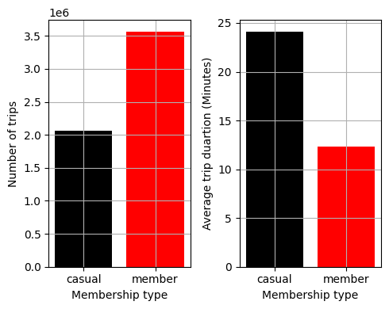

```python
#Total Number of trips for each rider type
Count= Counter(merged_divvy_data.member_casual)
print(Count)
count_of_category=list(Count.values())
type_membership= list(Count.keys())

#Average trip duration for each rider type
number_of_trips_per_category = merged_divvy_data.groupby('member_casual')['tripduration'].mean().reset_index()
number_of_trips_per_category.rename(columns={'tripduration':'average_trip_duration'},inplace=True)
print(number_of_trips_per_category)

#Visualization
fig,axes=plt.subplots(1,2,figsize=(5,4))
axes[0].bar(type_membership,height=count_of_category,color=['black','red'])
axes[1].bar(number_of_trips_per_category.member_casual,number_of_trips_per_category.average_trip_duration, color=['black','red'])
axes[0].grid(),axes[1].grid()
axes[0].set_xlabel('Membership type'), axes[1].set_xlabel('Membership type')
axes[0].set_ylabel('Number of trips'), axes[1].set_ylabel('Average trip duartion (Minutes)')
plt.tight_layout()
```

### Insights from the above visuals:

```python
#Average trip duration grouping by membership type and type of bike
avg_duration_per_ride_type = merged_divvy_data.groupby(['rideable_type','member_casual'])['tripduration'].mean().reset_index()
avg_duration_per_ride_type.rename(columns={'tripduration':'Average_trip_duration'},inplace=True)
avg_duration_per_ride_type
```

|  | rideable_type | member_casual | Average_trip_duration |
| --- | --- | --- | --- |
| 0 | classic_bike | casual | 37.837699 |
| 1 | classic_bike | member | 14.106986 |
| 2 | electric_bike | casual | 14.158659 |
| 3 | electric_bike | member | 11.005392 |
| 4 | electric_scooter | casual | 11.937651 |
| 5 | electric_scooter | member | 8.239676 |

```
member_casual        casual     member
rideable_type
classic_bike      37.837699  14.106986
electric_bike     14.158659  11.005392
electric_scooter  11.937651   8.239676
```

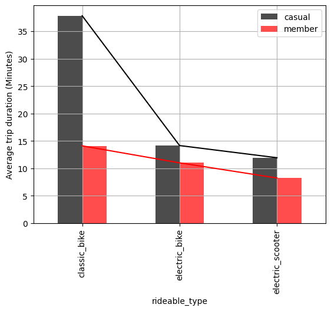

```python
##The Total number of trips Grouping by membership type and type of bike
pivot= avg_duration_per_ride_type.pivot(columns='member_casual',index='rideable_type',values='Average_trip_duration')
print(pivot)
#Visualization
pivot.plot(kind='bar',color=['black','red'],alpha=0.7)
plt.grid()
plt.plot(pivot.index, pivot.member,color='red')
plt.plot(pivot.index, pivot.casual,color='black')
plt.legend()
plt.ylabel('Average trip duration (Minutes)')
```

```
member_casual        casual     member
rideable_type
classic_bike      37.837699  14.106986
electric_bike     14.158659  11.005392
electric_scooter  11.937651   8.239676
```

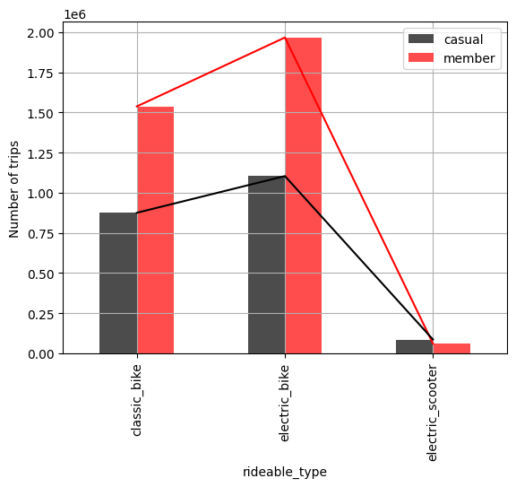

```python
#The Total number of trips Grouping by membership type and type of bike
trip_count_per_ride_type = merged_divvy_data.groupby(['rideable_type','member_casual'])['tripduration'].count().reset_index()
trip_count_per_ride_type.rename(columns={'tripduration':'trip_count'},inplace=True)
trip_count_pivot= trip_count_per_ride_type.pivot(columns='member_casual',index='rideable_type',values='trip_count')
print(pivot)
#Visualization
trip_count_pivot.plot(kind='bar',color=['black','red'],alpha=0.7)
plt.grid()

plt.plot(trip_count_pivot.index, trip_count_pivot.member,color='red')
plt.plot(trip_count_pivot.index, trip_count_pivot.casual,color='black')
plt.legend()
plt.ylabel('Number of trips')
```

|  | day | member_casual | tripduration |
| --- | --- | --- | --- |
| 0 | Friday | casual | 319711 |
| 1 | Friday | member | 523417 |
| 2 | Monday | casual | 240310 |
| 3 | Monday | member | 511250 |
| 4 | Saturday | casual | 425623 |
| 5 | Saturday | member | 466721 |
| 6 | Sunday | casual | 345288 |
| 7 | Sunday | member | 394196 |
| 8 | Thursday | casual | 260314 |
| 9 | Thursday | member | 555267 |
| 10 | Tuesday | casual | 222675 |
| 11 | Tuesday | member | 547804 |
| 12 | Wednesday | casual | 250365 |
| 13 | Wednesday | member | 565906 |

```
member_casual  casual  member
day
Monday         240310  511250
Tuesday        222675  547804
Wednesday      250365  565906
Thursday       260314  555267
Friday         319711  523417
Saturday       425623  466721
Sunday         345288  394196
```

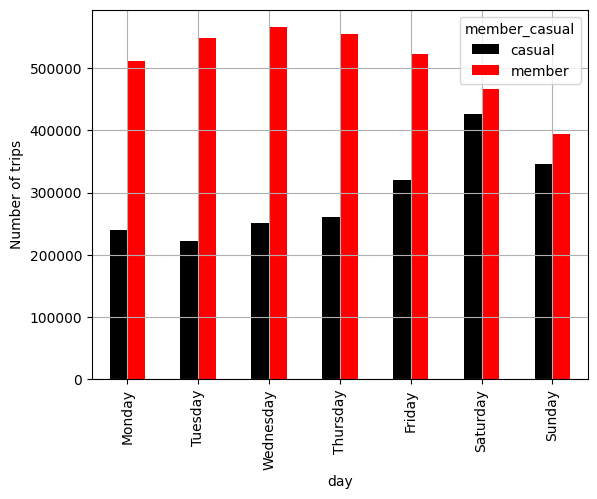

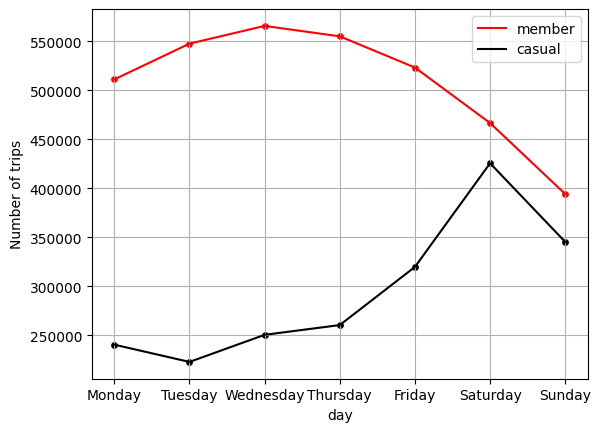

```python
#Weekly analysis of the usage patterns
merged_divvy_data['day']= merged_divvy_data['started_at'].dt.day_name()
trips_per_day = merged_divvy_data.groupby(['day','member_casual'])['tripduration'].count().reset_index()
display(trips_per_day)
day_order = ['Monday', 'Tuesday', 'Wednesday', 'Thursday', 'Friday', 'Saturday', 'Sunday']
trips_per_day.day =pd.Categorical(trips_per_day.day,categories=day_order,ordered=True)
trips_per_day.sort_values('day')
pivot_trips_per_day= trips_per_day.pivot(columns='member_casual', values='tripduration',index='day')
print(pivot_trips_per_day)
#Visualizations
pivot_trips_per_day.plot(kind='bar',color=['black','red'])
plt.ylabel('Number of trips')
plt.grid()
plt.figure()
plt.scatter(pivot_trips_per_day.index,pivot_trips_per_day.member,color='red',s=15)
plt.plot(pivot_trips_per_day.index,pivot_trips_per_day.member,label='member',color='red')
plt.scatter(pivot_trips_per_day.index,pivot_trips_per_day.casual,color='black',s=15)
plt.plot(pivot_trips_per_day.index,pivot_trips_per_day.casual,color='black',label='casual')
plt.legend()
plt.grid()
plt.ylabel('Number of trips')
plt.xlabel('day')
```

## New York Citibike dataset

The Divvy dataset was able to unravel various insights on the usage patterns of members and casual riders. But, the dataset fails to provide any information on the age and gender of thr users. Such inofrmation is required to understand the target audience. Hence, another bike-sharing company:citi's dataset from New York is analysed in the following section. The data was sourced,cleaned and analysed through big query and then imported here. However, a limitation of this dataset is that it ranges from 2013 to 2018 and may not be very accurately represntatitive of 2025 scenario. The SQL QUERIES ARE AS FOLLOWS

```
#QUERY 1
    SELECT
        birth_year,
        count(usertype)as number_of_subscribers,
        count(usertype)/(select count(*) from bigquery-public-data.new_york_citibike.citibike_trips where is_nan        (tripduration)=FALSE AND usertype="Subscriber") as subscriber_trip_fraction ,
        (select count(*) from bigquery-public-data.new_york_citibike.citibike_trips where is_nan(tripduration)=FALSE AND usertype="Subscriber") AS total_number_of_trips_by_subs

FROM
bigquery-public-data.new_york_citibike.citibike_trips
WHERE
 usertype = "Subscriber" AND IS_NAN(tripduration)=FALSE
GROUP BY
 birth_year
ORDER BY
 subscriber_trip_fraction DESC ;


#QUERY 2
SELECT
birth_year, COUNT(birth_year) AS trips_by_birth_year, COUNT(birth_year)*100/(SELECT COUNT(*) FROM  bigquery-public-data.new_york_citibike.citibike_trips WHERE IS_NAN(tripduration)=FALSE) AS percent_of_total_trips
FROM
bigquery-public-data.new_york_citibike.citibike_trips
WHERE
IS_NAN(tripduration)=FALSE
GROUP BY
birth_year
ORDER BY
birth_year;

#QUERY 3
SELECT
usertype,SUM(tripduration)/60 AS total_trip_duration,AVG(tripduration)/60 AS Average_trip_duration, COUNT(usertype) AS Number_of_trips
FROM
bigquery-public-data.new_york_citibike.citibike_trips
WHERE
IS_NAN(tripduration)= FALSE
GROUP BY
 usertype;

 #QUERY 4
 SELECT EXTRACT(YEAR FROM starttime)AS year,COUNT(*) AS num_subs
FROM bigquery-public-data.new_york_citibike.citibike_trips
WHERE IS_NAN(tripduration)=FALSE AND usertype= 'Subscriber'
GROUP BY year
order by year;

#QUERY 5
SELECT
        gender,
        count(usertype) as number_of_subscribers,
        (select count(*) from bigquery-public-data.new_york_citibike.citibike_trips where is_nan(tripduration)=FALSE AND gender="female") as total_male_users, (select count(*) from bigquery-public-data.new_york_citibike.citibike_trips where is_nan(tripduration)=FALSE AND gender="male") as total_female_users, count(usertype)*100/(select count(*) from bigquery-public-data.new_york_citibike.citibike_trips where is_nan(tripduration)=FALSE AND usertype="Subscriber") as subscriber_trip_percent, (select count(*) from bigquery-public-data.new_york_citibike.citibike_trips where is_nan(tripduration)=FALSE AND gender="unknown") as total_uknown_users

FROM
bigquery-public-data.new_york_citibike.citibike_trips
WHERE
 usertype = "Subscriber" AND IS_NAN(tripduration)=FALSE
GROUP BY
gender
```

**Note: There are 5 tables corresponding to 5 queries:**

```python
#Read and Display the data
citi_list= os.listdir('citi_cycle data/')
for g in range(len(citi_list)):
    globals()['citi'+str(g)]= pd.read_csv('citi_cycle data/'+citi_list[g])
    display(globals()['citi'+str(g)])
```

|  | gender | number_of_subscribers | total_male_users | total_female_users | subscriber_trip_percent | total_uknown_users |
| --- | --- | --- | --- | --- | --- | --- |
| 0 | male | 35308523 | 35611787 | 11376412 | 75.256501 | 6120522 |
| 1 | female | 11188711 | 35611787 | 11376412 | 23.847592 | 6120522 |
| 2 | unknown | 420338 | 35611787 | 11376412 | 0.895907 | 6120522 |

|  | birth_year | number_of_subscribers | subscriber_trip_fraction | total_number_of_trips_by_subs |
| --- | --- | --- | --- | --- |
| 0 | 1985.0 | 1935170 | 4.124617e-02 | 46917572 |
| 1 | 1986.0 | 1866590 | 3.978445e-02 | 46917572 |
| 2 | 1984.0 | 1846663 | 3.935973e-02 | 46917572 |
| 3 | 1988.0 | 1827755 | 3.895673e-02 | 46917572 |
| 4 | 1987.0 | 1814123 | 3.866617e-02 | 46917572 |
| ... | ... | ... | ... | ... |
| 103 | 1915.0 | 24 | 5.115354e-07 | 46917572 |
| 104 | 1890.0 | 18 | 3.836516e-07 | 46917572 |
| 105 | 1909.0 | 15 | 3.197096e-07 | 46917572 |
| 106 | 1889.0 | 13 | 2.770817e-07 | 46917572 |
| 107 | 1903.0 | 3 | 6.394193e-08 | 46917572 |

108 rows × 4 columns

|  | usertype | total_trip_duration | Average_trip_duration | Number_of_trips |
| --- | --- | --- | --- | --- |
| 0 | Customer | 2.213864e+08 | 35.758535 | 6191149 |
| 1 | Subscriber | 6.305580e+08 | 13.439698 | 46917572 |

|  | birth_year | trips_by_birth_year | percent_of_total_trips |
| --- | --- | --- | --- |
| 0 | NaN | 0 | 0.0000 |
| 1 | 1874.0 | 6 | 0.0000 |
| 2 | 1884.0 | 2 | 0.0000 |
| 3 | 1885.0 | 2202 | 0.0041 |
| 4 | 1886.0 | 157 | 0.0003 |
| ... | ... | ... | ... |
| 107 | 1998.0 | 131231 | 0.2471 |
| 108 | 1999.0 | 74922 | 0.1411 |
| 109 | 2000.0 | 35246 | 0.0664 |
| 110 | 2001.0 | 11150 | 0.0210 |
| 111 | 2002.0 | 723 | 0.0014 |

112 rows × 3 columns

|  | year | num_of_subs |
| --- | --- | --- |
| 0 | 2013 | 4370245 |
| 1 | 2014 | 7287721 |
| 2 | 2015 | 8626638 |
| 3 | 2016 | 9026384 |
| 4 | 2017 | 12441957 |
| 5 | 2018 | 5164627 |

```
[66.48347453142395, 21.067558753674373, 0.7914669984238558, 11.657499716477815]
```

[figure not shown]

```python
#some calculations
subs_ratio= list(citi0.number_of_subscribers*100/(citi0.total_female_users+citi0.total_male_users+citi0.total_uknown_users))
subs_ratio.append(100-sum(subs_ratio))

print(subs_ratio)
subs_ratio= np.array(subs_ratio)
gender_user_type = ['male subscribers','female subscribers','uknown subscribers','customers']
#Visualization
fig,axes=plt.subplots(3,3,figsize=(12,12))
axes[0,0].bar(citi1.birth_year,citi1.number_of_subscribers,color='red')
axes[0,2].bar(citi4.year,citi4.num_of_subs,color='black')
axes[0,1].bar(citi3.birth_year,citi3.trips_by_birth_year,color='red')
axes[1,1].pie(citi0.subscriber_trip_percent,labels=round(citi0.subscriber_trip_percent,2),colors=['red','black','grey'])
axes[1,1].legend(citi0.gender,bbox_to_anchor=(1,0))
axes[1,0].bar(citi0.gender, height=[citi0.total_male_users[0],citi0.total_uknown_users[0],citi0.total_female_users[0]],color=['red','black','grey'])
axes[1,2].pie(subs_ratio,labels=np.round(subs_ratio,2),colors=['red','black','grey','cyan'])
axes[1,2].legend(gender_user_type,bbox_to_anchor=(1,0))
axes[2,0].bar(citi2.usertype,citi2.total_trip_duration, color=['red','black'])
axes[2,1].bar(citi2.usertype,citi2.Average_trip_duration, color=['red','black'])
axes[2,2].bar(citi2.usertype,citi2.Number_of_trips, color=['red','black'])
axes[0,0].set_xlabel('birth year')
axes[0,0].set_ylabel('Number of Subscribers')
axes[0,1].set_xlabel('birth year')
axes[0,1].set_ylabel('Number of trips')
axes[0,2].set_xlabel('Year')
axes[0,2].set_ylabel('Number of Subrcribers')
axes[1,0].set_xlabel('gender')
axes[1,0].set_ylabel('Number of trips')
axes[1,1].set_title('Percentage of subscriber trips by gender')
axes[1,2].set_title('Percentage of trips by user type and gender')
axes[2,0].set_xlabel('user type')
axes[2,1].set_xlabel('user type')
axes[2,2].set_xlabel('user type')
axes[2,0].set_ylabel('Total trip duration')
axes[2,1].set_ylabel('Average trip duration')
axes[2,2].set_ylabel('Total number of trip')
plt.tight_layout()
```

## Insights from the Visuals

### Row 3 of Visuals

- The row 3 stats show a good allignment with the Divvy's data strengthening the credibility of insights.
- The inverse correlation observed between average duration and number of trips for both user types also matches with the previous analysis of Divvys data.

## Limitations

- The Divvys dataset doesn't include information about the amount spent on each trip making the analysis on cost related benefits of membership out of reach.
- Information on battery duration and battery percentage at the end and start of ride may help in understanding the reason for usage patterns electric bike and electric scooters by both the user types
- Divvys dataset doesn't have any personal information on the age and gender of the customers resulting in usage of other proxy datasets to gain insights on target audience.
- The proxy dataset of NY citi bikes is not representative of the current time period.

## Recommendations

- Men in the age between 23 to 33 years are most likely to buy an annual membership amongst the casual riders
- Reason for low bike-sharing trips and subscriptions by Women must be investigated through surveys
- Marketing must focus on the advantages of shorter bike-sharing trips and use it to market annual memberships emphasizing on the low cost.
- A discounted youth/student pass can encourage new target audience. However, more data-driven insights are required to support the hypothesis
- Battery life of electric bikes and scooters must be inspected and enhanced to balance the usage between all the three types of rides
- TCasual riders show high usage on weekends — Cyclistic could promote weekend membership discounts or partner with weekend events.
- Increasing in prices of single ride and full day passes on weekends can increase the advantages of choosing a membership option.